# Why Breaking Bad is the Greatest Show Ever

Jeffrey Waring

October 19, 2017

It’s no secret that I am a huge fan of the show ‘Breaking Bad’. I have always been impressed with how strong the show ended. Each of the 5 seasons improved upon the last until it concluded with an immaculate finale. This can be visualized using the user ratings from imdb http://www.imdb.com.

[figure not shown]

It’s so refreshing to me that this show chose to end at its peak, after only 5 seasons, rather than continue on into mediocrity. As shown above, the best of ‘Breaking Bad’ was its final few episodes.

Compare this against someother great (‘Futurama’, ‘The Wire’) and…not so great shows (‘True Blood’,‘Burn Notice’).

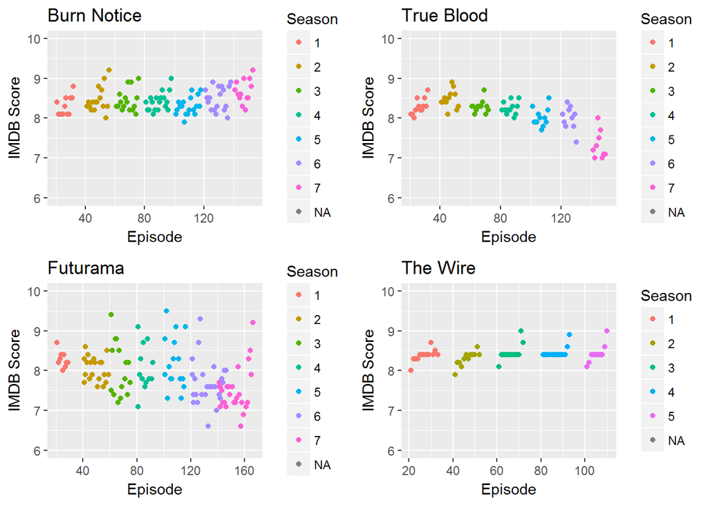

‘True Blood’ steadily declined after its 2nd season, as anyone who watched the show could attest.

I am someone disapointed that ‘Burn Notice’ rates so high so consistenly. Although I enjoyed the campy nature of the show, I certainly would not consider it high art. And I certainly would not rank it above ‘Futurama’, which had higher individual episodes, but IMDB users seemed to rank lower (particularly the last few seasons of the Comedy Central revival). Disapointing, and perhaps indicative of a flaw in crowdsourcing as a means of rating television shows.

### Methodology

User ratings by episode are scraped from the show’s imdb page using the chrome extension [Table Capture](https://chrome.google.com/webstore/detail/table-capture/iebpjdmgckacbodjpijphcplhebcmeop)